# Giardia, PCR+ analysis

Published

October 12, 2026

Modified

October 7, 2026

## File overview

The purpose of this file is to further investigate the discrepancy in Giardia PCR and IgG responses for the ECoMiD cohort.

In short, we found a larger than average proportion of PCR+ samples were IgG- for Giardia compared to all other pathogens in the panel.

The two plausible explanations we would like to investigate whether:

1. **PCR is overestimating** (different target than serology, perhaps capturing Giardia strain incidence that is not captured by serology)
2. **Luminex IgG is underestimating** (not enough exposure to seroconvert, bead issue, ect)

**Important to note:**

1. Childsets are coded PCR/IgG status at the **antigen** level from script 15
2. Childsets are coded conditional on a PCR+ result occurring before the *last occurrence* of an IgG result. This means if the PCR result was positive only at 24 months, the childset will be coded as PCR-. It also means if the only PCR+ result was at or after the last occurrence of an IgG result, the childset will be coded as PCR- (see table below). In other words, to classify children, PCR+ results were required to occur before the final available serology measurement. PCR+ detections observed only at the last serology timepoint were excluded, regardless if they were IgG+ or IgG-, because no subsequent IgG follow-up was available to assess seroconversion.
3. Due to exclusion criteria: 20 childsets were coded as PCR-, despite having a PCR+ result for VSP5_Giardia.

*PCR+ only counts if it occurs strictly before the last recorded IgG timepoint, or if a PCR+ at the last IgG timepoint is accompanied by at least one earlier PCR+ event*

| PCR status | IgG status | Coded as… |
| --- | --- | --- |
| +, at any timepoint before last IgG result | +, at any timepoint | PCR+IgG+ |
| +, at any timepoint before last IgG result | -, at all timepoints | PCR+IgG- |
| -, at all timepoints before last IgG result | +, at any timepoint | PCR-IgG+ |
| -, at all timepoints before last IgG result | -, at all timepoints | PCR-IgG- |

## System setup

```r
# Read in files
library(here)
source(here("R", "0-config.R"))
```

## Read in files

```r
# seropositivity individual level
# don't include MFI to avoid confusion with GPP MFI down the line!
sero_pos <- read_csv(here("..","..",
                      "data","serology","final","ecomid_serology_datasets",
                      "ecomid_sero_antigen_seropos_long_v02_20261007.csv")) %>% filter(antigen != "hlye") %>% select(-mfi, -log10mfi, -mficut, -mficut_desc) %>%
  mutate(community_type2 = case_when(community_type == "Rural Road" ~ "Rural",
                                    community_type == "Rural River" ~ "Rural",
                                    community_type == "Borbon" ~ "Borbón",
                                    community_type == "Esmeraldas" ~ "Esmeraldas"))


# pcr individual level
pcr <- readRDS(here("data/ecomid_pcr_analysis_data_2026-10-07.rds")) %>% ungroup() %>%
  rename(hhid = childid,
         sampleid = sample_ID) %>%
  mutate(childid = substr(sampleid, start = 1, stop = 6))

pcr$community_type <- as.character(pcr$community_type)
pcr <- pcr %>%
  mutate(community_type2 = case_when(community_type == "Rural Road" ~ "Rural",
                                    community_type == "Rural River" ~ "Rural",
                                    community_type == "Borbon" ~ "Borbón",
                                    community_type == "Esmeraldas" ~ "Esmeraldas")) %>% rename(timepoint = visit)
pcr$community_type2 <- factor(pcr$community_type2, levels = c("Esmeraldas", "Borbón", "Rural"))

# filter it down to the 369 children that were in both cohorts
pcr <- pcr %>% filter(childid %in% sero_pos$childid)

table(pcr$timepoint)
```

```
   3    6    9   12   15   18   24
4068 4407 4044 4277 3564 3861 3492
```

```r
table(pcr$pcr_assay)
```

```
  gpp   tac
15168 12545
```

```r
# tac raw results (ct values)
tac <- read_csv(here("../../data/tac-full/final/TAC_data_pathogensbysamples_CT_20260316.csv")) %>%
  select(-`...1`, -X, -Collection.Date, -Collection.Month, -Community.type, -Age, -Community, -season, -sex, -HH.ID)

# Luminex PCR: log calls
gpp <- read_rds(here("../../data/gpp-full/final/gpp_cleaned_files/gpp_final_calls_clean_20260610.rds")) %>% mutate(gpp_target = ifelse(gpp_target == "ETEC_LT", "LT-ETEC", gpp_target)) %>% mutate(timepoint = as.numeric(age)) %>% rename(sampleid = sample)

# Assay calls

assay <- read_rds(here("output/ecomid_seropos_pcr_alltargets.rds")) %>% filter(childid %in% pcr$childid)
```

## 1) Giardia

### A) TAC: CT values

Data clean: merge the ct values

```r
# create merging variable to pcr dataset
pcr2 <- pcr %>% mutate(id_tp =
                         paste0(substr(childid, start = 3, stop = 6),
                                sprintf("%02d", timepoint)))

# pivot tac ct values longer for joining
tac_long <- tac %>%
  pivot_longer(cols = 2:48, names_to = "tac_target",
               values_to = "ct_value")

# filter down to Giardia
tac_long <- tac_long %>% filter(tac_target == "Giardia_18S") %>% mutate(pathogen = "Giardia")

# join to Giardia PCR records
pcr_ct <- left_join(pcr2, tac_long, by = c("id_tp", "pathogen")) %>%
  filter(pathogen == "Giardia", pcr_assay == "tac")

# merge in IgG seroposivity at each timepoint
igg_ct <- left_join(pcr_ct,
                    sero_pos %>% select(childid, timepoint, seropos, pathogen) %>%
                      filter(pathogen == "Giardia"),
                    by = c("childid", "timepoint", "pathogen"))

# how much missing data (at limit of detection?)
print("No. unique children with CT value and IgG value")
```

```
[1] "No. unique children with CT value and IgG value"
```

```r
length(unique(igg_ct$childid))
```

```
[1] 362
```

```r
print("CT value, NAs")
```

```
[1] "CT value, NAs"
```

```r
table(is.na(igg_ct$ct_value))
```

```
FALSE  TRUE
  185   780
```

```r
print("Missing data: CT values")
```

```
[1] "Missing data: CT values"
```

```r
igg_ct %>%
  summarise(
    total_rows = n(),
    n_na = sum(is.na(ct_value)),
    percent_missing = round(n_na / total_rows * 100, 2)
  )
```

```
# A tibble: 1 × 3
  total_rows  n_na percent_missing
       <int> <int>           <dbl>
1        965   780            80.8
```

```r
print("Missing data: IgG")
```

```
[1] "Missing data: IgG"
```

```r
igg_ct %>%
  summarise(
    total_rows = n(),
    n_na = sum(is.na(seropos)),
    percent_missing = round(n_na / total_rows * 100, 2)
  )
```

```
# A tibble: 1 × 3
  total_rows  n_na percent_missing
       <int> <int>           <dbl>
1        965    71            7.36
```

Many NA values for CT values is likely due to limit of detection for the assay *will be for the 6, 12, 18 months samples

```r
# label seroposivity and TAC positivity
igg_ct <- igg_ct %>%
  mutate(seropos2 = ifelse(seropos == 1, "IgG+", "IgG-"))

unique(igg_ct$timepoint)
```

```
[1] 12 18  6
```

```r
igg_ct <- igg_ct %>% mutate(tacpos = ifelse(pcrpos == 1, "TAC+", "TAC-"))

table(igg_ct$tacpos, igg_ct$seropos2)
```

```
       IgG- IgG+
  TAC-  719   18
  TAC+  119   38
```

```r
igg_ct$ct_value <- as.numeric(igg_ct$ct_value)
```

```r
# Add in assay categorization that was completed in script 15

# How many of these PCR+ are missing a tac ct value (should be none)
igg_ct %>%
  filter(pcrpos == 1) %>%
  summarise(
    total_rows = n(),
    n_na = sum(is.na(ct_value)),
    percent_missing = round(n_na / total_rows * 100, 2)
  )
```

```
# A tibble: 1 × 3
  total_rows  n_na percent_missing
       <int> <int>           <dbl>
1        168     0               0
```

```r
# merge in childset-level PCR/IgG classification from assay object
igg_ct2 <- igg_ct %>% ungroup() %>%
  left_join(assay %>% distinct(childid, pathogen, assay_pos),
            by = c("childid", "pathogen")) %>%
  filter(pcrpos == 1,
         assay_pos == "PCR+ IgG+" |
           assay_pos == "PCR+ IgG-") # filter down to those categorized in the spaghetti plots as PCR+

# duplicate data and label as "Overall"
igg_ct_overall <- igg_ct2 %>%
  mutate(community_type2 = "Overall")

# combine with original community level data
igg_ct_combined <- bind_rows(igg_ct2, igg_ct_overall)

# assign levels
igg_ct_combined$community_type2 <-
  factor(igg_ct_combined$community_type2,
         levels = c("Esmeraldas", "Borbón", "Rural", "Overall"))

#------------#
# Code Check #
#------------#

# total TAC+ results before assay_pos filter
cat("Total TAC+ results before assay_pos filter")
```

```
Total TAC+ results before assay_pos filter
```

```r
igg_ct %>% filter(pcrpos == 1) %>% nrow()
```

```
[1] 168
```

```r
# TAC+ results after filtering to PCR+ IgG+ and PCR+ IgG- only
cat("TAC+ results after assay_pos filter")
```

```
TAC+ results after assay_pos filter
```

```r
igg_ct2 %>% nrow()
```

```
[1] 158
```

```r
cat("Total TAC+ data excluded")
```

```
Total TAC+ data excluded
```

```r
(igg_ct %>% filter(pcrpos == 1) %>% nrow()) - (igg_ct2 %>% nrow())
```

```
[1] 10
```

#### i) Mann-Whitney U test

```r
# repeated measures: number of children with a PCR+ TAC value

cat("Number of children with repeated measures")
```

```
Number of children with repeated measures
```

```r
igg_ct_combined %>% group_by(childid) %>%
  summarise(n_tacpos = n()) %>%
  group_by(n_tacpos) %>%
  summarise(n_children = n())
```

```
# A tibble: 3 × 2
  n_tacpos n_children
     <int>      <int>
1        2        106
2        4         23
3        6          2
```

```r
# counts for the plot
igg_ct_combined %>%
  distinct(childid, assay_pos) %>%
  count(assay_pos) %>%
  print()
```

```
# A tibble: 2 × 2
  assay_pos     n
  <chr>     <int>
1 PCR+ IgG+    62
2 PCR+ IgG-    69
```

```r
# Community-specific Mann-Whitney
igg_ct_combined$assay_pos <- factor(igg_ct_combined$assay_pos,
                                    levels = c("PCR+ IgG-", "PCR+ IgG+"))
levels(igg_ct_combined$assay_pos)
```

```
[1] "PCR+ IgG-" "PCR+ IgG+"
```

```r
mannwhitney_ct <- igg_ct_combined %>%
  filter(!is.na(ct_value), !is.na(assay_pos)) %>%
  group_by(community_type2) %>%
  summarise(
    test = list(wilcox.test(ct_value ~ assay_pos, conf.int = TRUE)),
    total_n = n(),
    n_IgG_neg = sum(assay_pos == "PCR+ IgG-"),
    n_IgG_pos = sum(assay_pos == "PCR+ IgG+")
  ) %>%
  mutate(
    W = sapply(test, \(x) as.numeric(x$statistic)),
    U = W - (n_IgG_neg * (n_IgG_neg + 1)) / 2,
    p_value = round(sapply(test, \(x) x$p.value), 5),
    conf_low = sapply(test, \(x) x$conf.int[1]),
    conf_high = sapply(test, \(x) x$conf.int[2])
  ) %>%
  select(-test) %>%
  mutate(p_value_print = ifelse(p_value < 0.001, "p < 0.001", paste0("p = ", sprintf("%1.3f", p_value))))

mannwhitney_ct
```

```
# A tibble: 4 × 10
  community_type2 total_n n_IgG_neg n_IgG_pos     W     U p_value conf_low
  <fct>             <int>     <int>     <int> <dbl> <dbl>   <dbl>    <dbl>
1 Esmeraldas           32        13        19   223   132 0.00004     6.16
2 Borbón               55        17        38   487   334 0.00233     1.94
3 Rural                71        46        25   657  -424 0.329      -1.77
4 Overall             158        76        82  4292  1366 0.00004     2.00
# ℹ 2 more variables: conf_high <dbl>, p_value_print <chr>
```

#### ii) CT plot

The analysis here is done for IgG status at the entire childset level (over the course of the study) and is subset to timepoints when TAC was positive

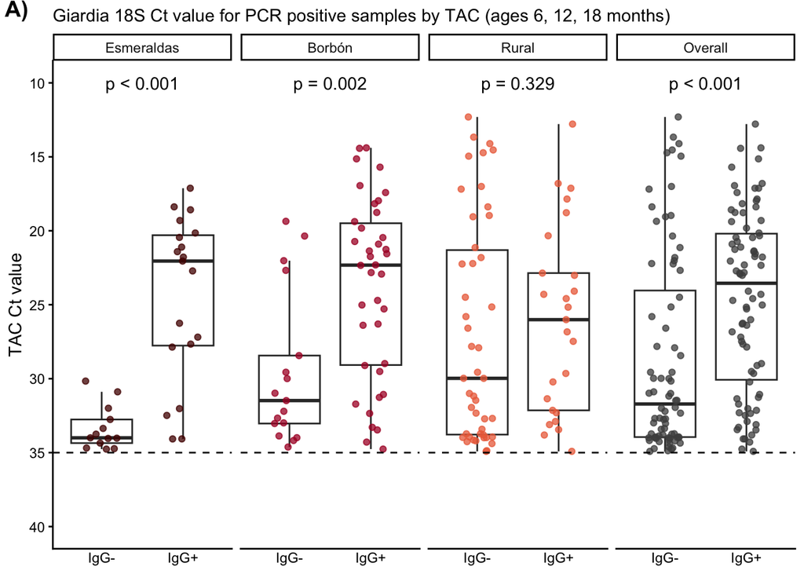

```r
set.seed(12345) # set seed for consistent point jitter

tac_giardia <- ggplot(
  igg_ct_combined,
  aes(x = assay_pos, y = ct_value)
) +
  geom_boxplot(notch = FALSE, outlier.shape = NA) +
  geom_jitter(
    aes(color = factor(community_type2)),
    alpha = 0.75, position = position_jitter(width = 0.2, height = 0, seed = 12345)
  ) +
  geom_hline(yintercept = 35, color = "black", linetype = "dashed") +
  facet_grid(~ community_type2) +
  scale_y_reverse(
    limits = c(10, 40),
    breaks = seq(10, 40, 5)
  ) +
  geom_text(data = mannwhitney_ct, aes(x = 1.5, y = 10, label = p_value_print)) +
  scale_x_discrete(labels = c("IgG-", "IgG+")) +
  scale_color_manual(
    values = c(
      "Esmeraldas" = nytpal[1],
      "Borbón" = nytpal[2],
      "Rural" = nytpal[3],
      "Overall" = "gray30"
    )
  ) +
  theme_classic() +
  theme(
    panel.grid = element_blank(),
    axis.ticks.x = element_blank(),
    axis.title.x = element_blank(),
    legend.position = "none"
  ) +
  labs(
    subtitle = "Giardia 18S Ct value for PCR positive samples by TAC (ages 6, 12, 18 months)",
    y = "TAC Ct value", x = "child seroconversion status",
    color = ""
  )

tac_giardia <- tac_giardia +
  labs(tag = "A)") +
  theme(
    plot.tag = element_text(size = 14, face = "bold"),
    plot.tag.position = c(0.01, 1)
  )
tac_giardia
```

```r
#ggsave(here("figures/giardia_ct_values_4panel.tiff"), tac_giardia,
#  width = 200,
#  height = 100,
#  units = "mm")
```

### B) Luminex: MFI values

```r
# create mfi df
# note: some pathogens have multiple PCR targets so the merge is not 1-to-1;
# Giardia has a single GPP target so this is fine here

gpp <- gpp %>% rename(id_tp = id_time)

pcr_mfi <- left_join(pcr2 %>%
                       filter(pcr_assay == "gpp") %>%
                       select(id_tp, pathogen, pcrpos, timepoint, childid),
                     gpp %>% select(-childid),
                     by = c("id_tp", "pathogen", "timepoint")) %>%
  filter(pathogen == "Giardia")

# join in the seropositivity and community data; fill in community for NA rows due to 3 month and 15 month missing in serology
igg_mfi <- left_join(pcr_mfi %>% ungroup(),
                     sero_pos %>% ungroup() %>%
                       filter(pathogen == "Giardia", antigen == "vsp5") %>%
                       select(childid, timepoint, pathogen, seropos) %>%
                       distinct(),
                     by = c("childid", "timepoint", "pathogen"))

# join in community
igg_mfi <- left_join(igg_mfi, sero_pos %>% distinct(childid, community, community_name,
                              community_type2), by = c("childid"))

igg_mfi$community_type2 <- factor(igg_mfi$community_type2, levels = c("Esmeraldas", "Borbón", "Rural"))

 # label seroposivity and GPP positivity
igg_mfi <- igg_mfi %>%
  mutate(seropos2 = ifelse(seropos == 1, "IgG+", "IgG-"))

unique(igg_mfi$timepoint)
```

```
[1] 15 24  3  9
```

```r
igg_mfi <- igg_mfi %>% mutate(gpppos = ifelse(pcrpos == 1, "GPP+", "GPP-"))
table(igg_mfi$gpppos, igg_mfi$seropos2)
```

```
       IgG- IgG+
  GPP-  425   13
  GPP+   89   55
```

```r
igg_mfi$mfi <- as.numeric(igg_mfi$mfi)

print("Missing data: PCR MFI values")
```

```
[1] "Missing data: PCR MFI values"
```

```r
igg_mfi %>%
  summarise(
    total_rows = n(),
    n_mfi_na = sum(is.na(mfi)),
    percent_missing = round(n_mfi_na / total_rows * 100, 2)
  )
```

```
# A tibble: 1 × 3
  total_rows n_mfi_na percent_missing
       <int>    <int>           <dbl>
1       1264        0               0
```

```r
# merge in the assay classification
igg_mfi <- igg_mfi %>% ungroup() %>%
  left_join(assay %>% distinct(childid, pathogen, assay_pos),
                     by = c("childid", "pathogen"))

# filter to GPP+ samples
# assay_pos status was already assigned excluding the 24 month timepoint/end timepoints
igg_mfi2 <- igg_mfi %>%
  filter(pcrpos == 1,
         assay_pos == "PCR+ IgG+" |
           assay_pos == "PCR+ IgG-")

# duplicate data and label as "Overall"
igg_mfi_overall <- igg_mfi2 %>%
  mutate(community_type2 = "Overall")

# combine with original community level data
igg_mfi_combined <- bind_rows(igg_mfi2, igg_mfi_overall)

# assign levels
igg_mfi_combined$community_type2 <-
  factor(igg_mfi_combined$community_type2,
         levels = c("Esmeraldas", "Borbón", "Rural", "Overall"))

#------------#
# Code Check #
#------------#

# total GPP+ results before assay_pos filter
cat("Total GPP+ results before assay_pos filter")
```

```
Total GPP+ results before assay_pos filter
```

```r
igg_mfi %>% filter(pcrpos == 1) %>% nrow()
```

```
[1] 254
```

```r
# GPP+ results after filtering to PCR+ IgG+ and PCR+ IgG- only
cat("GPP+ results after assay_pos filter")
```

```
GPP+ results after assay_pos filter
```

```r
igg_mfi2 %>% nrow()
```

```
[1] 190
```

```r
cat("Total GPP+ data excluded")
```

```
Total GPP+ data excluded
```

```r
(igg_mfi %>% filter(pcrpos == 1) %>% nrow()) - (igg_mfi2 %>% nrow())
```

```
[1] 64
```

#### i) Mann-Whitney U test

```r
# get table of sample distribution
igg_mfi2 %>% group_by(timepoint) %>%
  filter(gpp_target_pos == "POS") %>%
  summarise(n_gpppos = n())
```

```
# A tibble: 4 × 2
  timepoint n_gpppos
      <dbl>    <int>
1         3       19
2         9       23
3        15       73
4        24       75
```

```r
# note that 24 month GPP+ samples are included if they had a previous GPP+ result

# repeated measures: GPP+ timepoints coded as GPP+ after exclusion criteria applied
igg_mfi2 %>% group_by(childid) %>%
  filter(gpp_target_pos == "POS") %>%
  summarise(n_pcrpos = n()) %>%
  group_by(n_pcrpos) %>%
  summarise(n_children = n())
```

```
# A tibble: 3 × 2
  n_pcrpos n_children
     <int>      <int>
1        1         87
2        2         38
3        3          9
```

```r
###-------------------------------------------------------------------###
## Mann-Whitney U test (ignoring repeated measures and community type) ##
###-------------------------------------------------------------------###
igg_mfi_combined$assay_pos <- factor(igg_mfi_combined$assay_pos, levels = c("PCR+ IgG-", "PCR+ IgG+"))
levels(igg_mfi_combined$assay_pos)
```

```
[1] "PCR+ IgG-" "PCR+ IgG+"
```

```r
cat("Mann Whitney U test, by community, MFI")
```

```
Mann Whitney U test, by community, MFI
```

```r
mannwhitney_mfi <- igg_mfi_combined %>%
  filter(!is.na(mfi), !is.na(assay_pos)) %>%
  group_by(community_type2) %>%
  summarise(
    test = list(tryCatch(
      wilcox.test(mfi ~ assay_pos, conf.int = TRUE),
      error = function(e) NULL
    )),
    total_n = n(),
    n_IgG_neg = sum(assay_pos == "PCR+ IgG-"),
    n_IgG_pos = sum(assay_pos == "PCR+ IgG+")
  ) %>%
  mutate(
    W          = sapply(test, \(x) if (is.null(x)) NA_real_ else as.numeric(x$statistic)),
    p_value    = sapply(test, \(x) if (is.null(x)) NA_real_ else round(x$p.value, 5)),
    conf_low   = sapply(test, \(x) if (is.null(x)) NA_real_ else x$conf.int[1]),
    conf_high  = sapply(test, \(x) if (is.null(x)) NA_real_ else x$conf.int[2])
  ) %>%
  select(-test) %>%
  mutate(p_value_print = case_when(
    is.na(p_value)   ~ "N/A",
    p_value < 0.001  ~ "p < 0.001",
    TRUE             ~ paste0("p = ", sprintf("%1.3f", p_value))
  ))

mannwhitney_mfi
```

```
# A tibble: 4 × 9
  community_type2 total_n n_IgG_neg n_IgG_pos     W p_value conf_low conf_high
  <fct>             <int>     <int>     <int> <dbl>   <dbl>    <dbl>     <dbl>
1 Esmeraldas           39        21        18   48  0.00002   -1678.     -724.
2 Borbón               66        21        45  222  0.0004    -1459      -436.
3 Rural                85        58        27  660. 0.249      -672.      119.
4 Overall             190       100        90 2793  0.00001   -1035.     -340.
# ℹ 1 more variable: p_value_print <chr>
```

#### ii) MFI plot

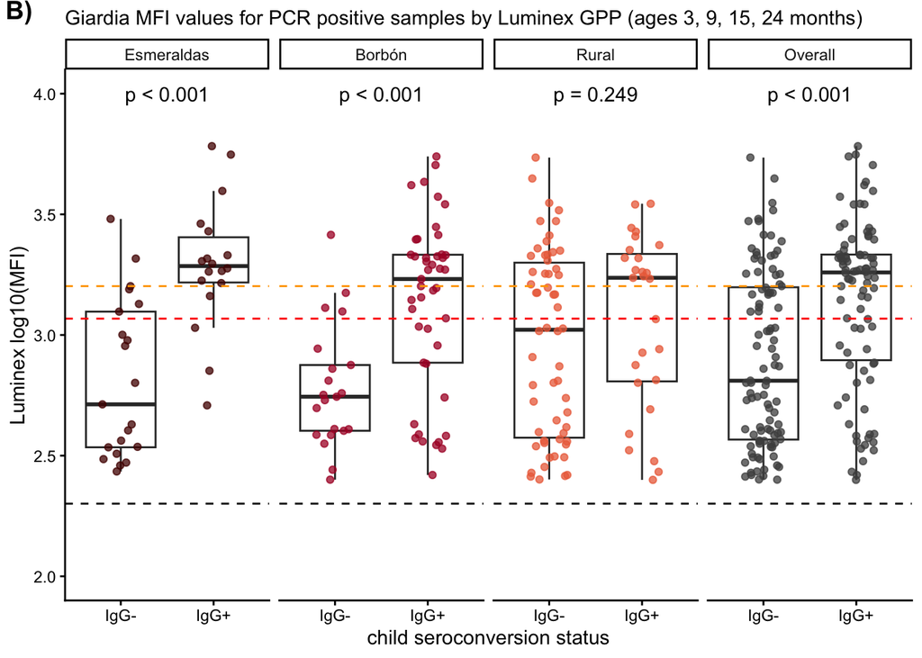

```r
set.seed(12335) # set seed for consistent jitter

gpp_giardia <- ggplot(
  igg_mfi_combined,
  aes(x = assay_pos, y = log10(mfi))
) +
  geom_boxplot(notch = FALSE, outlier.shape = NA) +
  geom_jitter(
    aes(color = community_type2),
    alpha = 0.75, position = position_jitter(width = 0.2, height = 0, seed = 12345)
  ) +
  geom_hline(yintercept = log10(200), color = "black", linetype = "dashed") +
  geom_hline(yintercept = log10(1169), color = "red", linetype = "dashed") + #low positive mean MFI value from xtag GPP user manual page 132
  geom_hline(yintercept = log10(1594), color = "orange", linetype = "dashed") + #moderate positive mean MFI
  geom_text(data = mannwhitney_mfi, aes(x = 1.5, y = 4, label = p_value_print)) +
  facet_grid(~ community_type2) +
  scale_y_continuous(
    limits = c(2, 4),
    breaks = seq(2, 4, 0.5)
  ) +
  scale_x_discrete(labels = c("IgG-", "IgG+")) +
  scale_color_manual(
    values = c(
      "Esmeraldas" = nytpal[1],
      "Borbón" = nytpal[2],
      "Rural" = nytpal[3],
      "Overall" = "gray30"
    )
  ) +
  theme_classic() +
  theme(
    panel.grid = element_blank(),
    legend.position = "none"
  ) +
  labs(
    subtitle = "Giardia MFI values for PCR positive samples by Luminex GPP (ages 3, 9, 15, 24 months)",
    y = "Luminex log10(MFI)", x = "child seroconversion status"
  )

gpp_giardia <- gpp_giardia +
  labs(tag = "B)") +
  theme(
    plot.tag = element_text(size = 14, face = "bold"),
    plot.tag.position = c(0.01, 1)
  )

gpp_giardia
```

```r
#ggsave(here("figures/supp_giardia_mfi_byurbanicity.tiff"), gpp_giardia, device = "tiff", height = 120, width = 200, units = "mm")
```

### C) Aggregate figure: tac and gpp

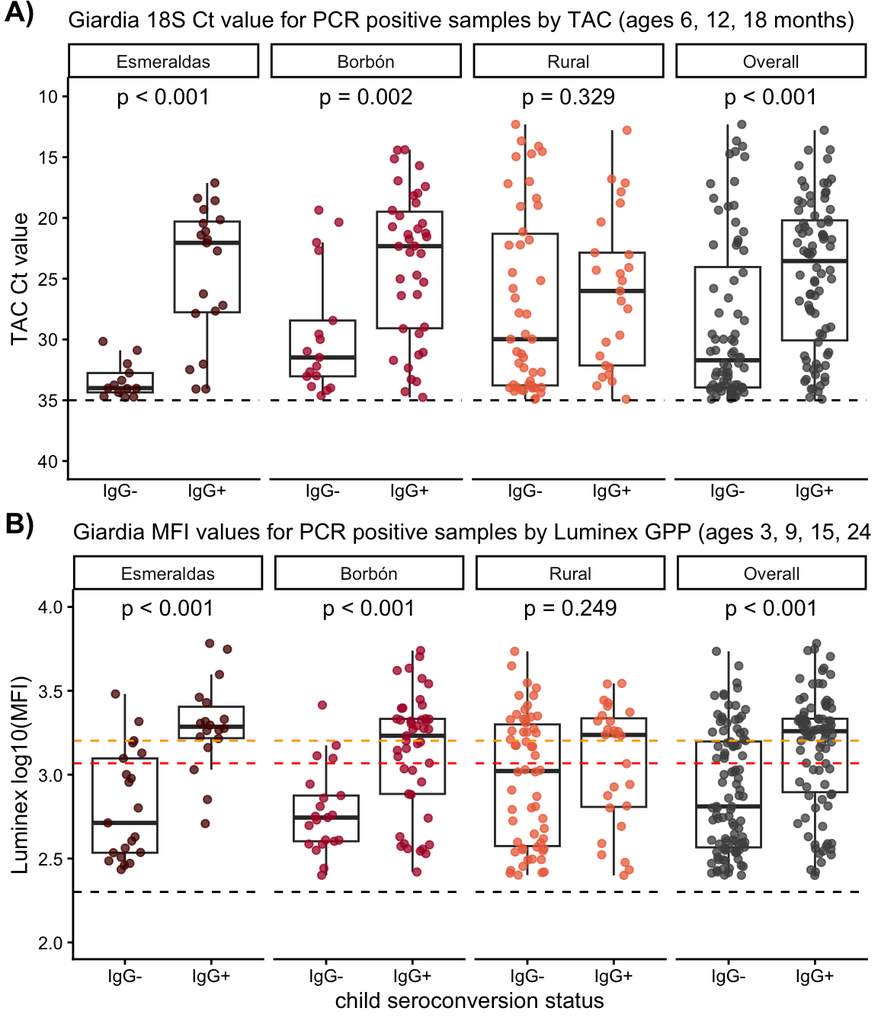

```r
agg_giardia <- plot_grid(tac_giardia, gpp_giardia, ncol = 1)
agg_giardia
```

```r
ggsave(here("figures/suppfig6_giardia_mfi_ct_byurbanicity_8panel.tiff"), agg_giardia, device = "tiff", height = 180, width = 200, units = "mm")
```